# Stout_casestudy_1

```python
import pandas as pd
import numpy as np
import matplotlib.pyplot as plt
import seaborn as sns
from sklearn.model_selection import train_test_split
from sklearn.impute import SimpleImputer
import chart_studio.plotly as py
import plotly.offline as po
import plotly.graph_objs as pg
%matplotlib inline
from wordcloud import WordCloud
from tabulate import tabulate
import warnings
warnings.filterwarnings('ignore', message='foo bar')
```

```python
data=pd.read_csv("C:/Users/deeps/OneDrive/Desktop/Ms/Interview/Case1/loans_full_schema.csv")
data.head(10).style.background_gradient()
```

|  | emp_title | emp_length | state | homeownership | annual_income | verified_income | debt_to_income | annual_income_joint | verification_income_joint | debt_to_income_joint | delinq_2y | months_since_last_delinq | earliest_credit_line | inquiries_last_12m | total_credit_lines | open_credit_lines | total_credit_limit | total_credit_utilized | num_collections_last_12m | num_historical_failed_to_pay | months_since_90d_late | current_accounts_delinq | total_collection_amount_ever | current_installment_accounts | accounts_opened_24m | months_since_last_credit_inquiry | num_satisfactory_accounts | num_accounts_120d_past_due | num_accounts_30d_past_due | … |
| --- | --- | --- | --- | --- | --- | --- | --- | --- | --- | --- | --- | --- | --- | --- | --- | --- | --- | --- | --- | --- | --- | --- | --- | --- | --- | --- | --- | --- | --- | --- |
| 0 | global config engineer | 3.000000 | NJ | MORTGAGE | 90000.000000 | Verified | 18.010000 | nan | nan | nan | 0 | 38.000000 | 2001 | 6 | 28 | 10 | 70795 | 38767 | 0 | 0 | 38.000000 | 0 | 1250 | 2 | 5 | 5.000000 | 10 | 0.000000 | 0 | … |
| 1 | warehouse office clerk | 10.000000 | HI | RENT | 40000.000000 | Not Verified | 5.040000 | nan | nan | nan | 0 | nan | 1996 | 1 | 30 | 14 | 28800 | 4321 | 0 | 1 | nan | 0 | 0 | 0 | 11 | 8.000000 | 14 | 0.000000 | 0 | … |
| 2 | assembly | 3.000000 | WI | RENT | 40000.000000 | Source Verified | 21.150000 | nan | nan | nan | 0 | 28.000000 | 2006 | 4 | 31 | 10 | 24193 | 16000 | 0 | 0 | 28.000000 | 0 | 432 | 1 | 13 | 7.000000 | 10 | 0.000000 | 0 | … |
| 3 | customer service | 1.000000 | PA | RENT | 30000.000000 | Not Verified | 10.160000 | nan | nan | nan | 0 | nan | 2007 | 0 | 4 | 4 | 25400 | 4997 | 0 | 1 | nan | 0 | 0 | 1 | 1 | 15.000000 | 4 | 0.000000 | 0 | … |
| 4 | security supervisor | 10.000000 | CA | RENT | 35000.000000 | Verified | 57.960000 | 57000.000000 | Verified | 37.660000 | 0 | nan | 2008 | 7 | 22 | 16 | 69839 | 52722 | 0 | 0 | nan | 0 | 0 | 1 | 6 | 4.000000 | 16 | 0.000000 | 0 | … |
| 5 | nan | nan | KY | OWN | 34000.000000 | Not Verified | 6.460000 | nan | nan | nan | 1 | 3.000000 | 1990 | 6 | 32 | 12 | 42100 | 3898 | 0 | 0 | 60.000000 | 0 | 0 | 0 | 2 | 5.000000 | 12 | 0.000000 | 0 | … |
| 6 | hr | 10.000000 | MI | MORTGAGE | 35000.000000 | Source Verified | 23.660000 | 155000.000000 | Not Verified | 13.120000 | 0 | nan | 2004 | 1 | 12 | 10 | 291852 | 18916 | 0 | 0 | nan | 0 | 0 | 2 | 1 | 9.000000 | 10 | 0.000000 | 0 | … |
| 7 | police | 10.000000 | AZ | MORTGAGE | 110000.000000 | Source Verified | 16.190000 | nan | nan | nan | 1 | 19.000000 | 2005 | 1 | 30 | 15 | 342336 | 60805 | 0 | 0 | 71.000000 | 0 | 0 | 2 | 4 | 7.000000 | 15 | nan | 0 | … |
| 8 | parts | 10.000000 | NV | MORTGAGE | 65000.000000 | Source Verified | 36.480000 | nan | nan | nan | 1 | 18.000000 | 1998 | 3 | 35 | 21 | 283190 | 69561 | 0 | 0 | 18.000000 | 0 | 0 | 6 | 10 | 4.000000 | 21 | 0.000000 | 0 | … |
| 9 | 4th person | 3.000000 | IL | RENT | 30000.000000 | Not Verified | 18.910000 | nan | nan | nan | 0 | nan | 2001 | 0 | 9 | 6 | 33114 | 17768 | 0 | 0 | nan | 0 | 0 | 1 | 5 | 17.000000 | 6 | 0.000000 | 0 | … |

```python
#Analyse duplicates in the dataset.
duplicatedRows=data[data.duplicated()]
print("Number of duplicate datapoints are:",len(duplicatedRows))
```

```
Number of duplicate datapoints are: 0
```

### Observation:

The Given data points have no duplicates.

Objectives:

• Describe the dataset and any issues with it.

• Generate a minimum of 5 unique visualizations using the data and write a brief description of your observations. Additionally, all attempts should be made to make the visualizations visually appealing.

• Create a feature set and create a model which predicts interest rate using at least 2 algorithms. Describe any data cleansing that must be performed and analysis when examining the data.

• Visualize the test results and propose enhancements to the model, what would you do if you had more time. Also describe assumptions you made and your approach.

## Data Analysis

```python
print(f"There are {data.shape[0]} rows and {data.shape[1]} columns in the dataframe")
print()
print()
print("Column names:",list(data.columns))
```

```
There are 10000 rows and 55 columns in the dataframe


Column names: ['emp_title', 'emp_length', 'state', 'homeownership', 'annual_income', 'verified_income', 'debt_to_income', 'annual_income_joint', 'verification_income_joint', 'debt_to_income_joint', 'delinq_2y', 'months_since_last_delinq', 'earliest_credit_line', 'inquiries_last_12m', 'total_credit_l…
```

```python
data.info()
```

```
<class 'pandas.core.frame.DataFrame'>
RangeIndex: 10000 entries, 0 to 9999
Data columns (total 55 columns):
 #   Column                            Non-Null Count  Dtype
---  ------                            --------------  -----
 0   emp_title                         9167 non-null   object
 1   emp_length                        9183 non-null   float64
 2   state                             10000 non-null  object
 3   homeownership                     10000 non-null  object
 4   annual_income                     10000 non-null  float64
 5   verified_income                   10000 non-null  object
 6   debt_to_income                    9976 non-null   float64
 7   annual_income_joint               1495 non-null   float64
 8   verification_income_joint         1455 non-null   object
 9   debt_to_income_joint              1495 non-null   float64
```

[output cut: 47 more lines]

### Obserivation

The Given dataset contains 17 float values , 25 integer values and 13 String values .

It is also seen that the dataframe utilized 4.2 MB of data.

#### 1.emp_title

```python
print("Number of NaN values in emp_table column :", data["emp_title"].isna().sum())
```

```
Number of NaN values in emp_table column : 833
```

```python
data["emp_title"] = data["emp_title"].fillna("")
```

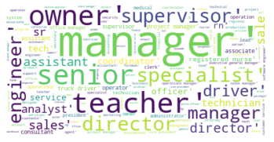

```python
wc = WordCloud(background_color="white", max_words=1000)
wc.generate(str(list(data["emp_title"])))
plt.imshow(wc,interpolation="bilinear")
plt.axis("off")
plt.show()
```

#### Observation:

Based on the Word-Cloud plot we can see that top employee types are manager , owner , specialist , senior and teacher.

From the Word-Cloud we can also see that he data looks fine and thus I go forward with other features.

```python
interest_max=data.interest_rate.max()
interest_min=data.interest_rate.min()
print("The Maximum  interest is:",str(interest_max))
print("The Minimum  interest is:",str(interest_min))
```

```
The Maximum  interest is: 30.94
The Minimum  interest is: 5.31
```

```python
#Analysis of  interest for all the Manager employee titles.
mean_interest_rate_manager=data.loc[data.emp_title.str.contains("manager")].interest_rate.mean()
print("The Mean  interest for Manager is :"+str(mean_interest_rate_manager))
```

```
The Mean  interest for Manager is :12.502513128282077
```

```python
#Find the mean interest for top employee titles
emp_list = ["manager","specialist","teacher","owner","senior","junior"]

for emp in emp_list:
    mean_emp=mean_interest_rate_manager=data.loc[data.emp_title.str.contains(emp)].interest_rate.mean()
    print(emp+" has the mean:",mean_emp)
```

```
manager has the mean: 12.502513128282077
specialist has the mean: 12.48664092664092
teacher has the mean: 12.234185185185181
owner has the mean: 11.670789473684211
senior has the mean: 11.556412556053802
junior has the mean: 15.934999999999999
```

### Observation:

We can see that senior has an averge of interest lesser than the junior , it may be analysed that due to good credit score senior has a lesser interest value.

### 2.state

```python
state_length=data["state"].isna().sum()
print("Number of NaN values in state column :", state_length)

if state_length==0:
    print("NAN values are not found and missing values handling is not required.")
else:
    print("NAN values are present.")
```

```
Number of NaN values in state column : 0
NAN values are not found and missing values handling is not required.
```

```python
a=data.groupby(['state']).mean()['interest_rate']
print(tabulate(a.to_frame(), headers='keys', tablefmt='psql'))
```

```
+---------+-----------------+
| state   |   interest_rate |
|---------+-----------------|
| AK      |         11.337  |
| AL      |         12.7875 |
| AR      |         13.1484 |
| AZ      |         12.1557 |
| CA      |         12.3236 |
| CO      |         12.2333 |
| CT      |         13.4698 |
| DC      |         12.4526 |
| DE      |         12.54   |
| FL      |         12.7106 |
| GA      |         12.3246 |
| HI      |         14.7794 |
| ID      |         12.5297 |
| IL      |         12.1081 |
| IN      |         11.8277 |
| KS      |         11.7322 |
| KY      |         12.7859 |
| LA      |         12.3745 |
| MA      |         12.0518 |
| MD      |         12.5901 |
| ME      |         10.7388 |
| MI      |         12.4281 |
| MN      |         12.202  |
| MO      |         12.3436 |
| MS      |         12.9925 |
| MT      |         12.8825 |
| NC      |         11.9095 |
| ND      |         14.4236 |
| NE      |         11.507  |
| NH      |         12.0113 |
| NJ      |         12.012  |
| NM      |         13.1286 |
| NV      |         12.7361 |
| NY      |         12.7272 |
| OH      |         13.0271 |
| OK      |         12.7581 |
| OR      |         12.6472 |
| PA      |         12.1629 |
| RI      |         12.8777 |
| SC      |         12.892  |
| SD      |         11.73   |
| TN      |         12.3772 |
| TX      |         12.2204 |
| UT      |         11.9267 |
| VA      |         12.3702 |
| VT      |         13.3396 |
| WA      |         12.7366 |
| WI      |         12.2447 |
| WV      |         12.555  |
| WY      |         12.5716 |
+---------+-----------------+
```

### Observation:

From the observation we can see that HI has the highest interest average value.

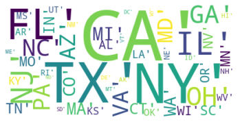

```python
wc = WordCloud(background_color="white", max_words=1000)
wc.generate(str(list(data["state"])))
plt.imshow(wc,interpolation="bilinear")
plt.axis("off")
plt.show()
```

### Observation:

Word-Cloud depicts that CA,TX,NY,NJ,FL have the highest values in the given data.

```python
#Find the mean interest for top employee titles
state_list = ["NY","NJ","AR","FL","VT","HI","TX","CA","CO","ME"]

list_state=[]
for state in state_list:
    mean_state=data.loc[data.state.str.contains(state)].interest_rate.mean()
    list_state.append([state, mean_state])

state_pi = pd.DataFrame(list_state,columns=["state","interest_rate_mean"])
print(tabulate(state_pi, headers='keys', tablefmt='psql'))
```

```
+----+---------+----------------------+
|    | state   |   interest_rate_mean |
|----+---------+----------------------|
|  0 | NY      |              12.7272 |
|  1 | NJ      |              12.012  |
|  2 | AR      |              13.1484 |
|  3 | FL      |              12.7106 |
|  4 | VT      |              13.3396 |
|  5 | HI      |              14.7794 |
|  6 | TX      |              12.2204 |
|  7 | CA      |              12.3236 |
|  8 | CO      |              12.2333 |
|  9 | ME      |              10.7388 |
+----+---------+----------------------+
```

```python
#View the US States and their averge  interest values in Map.
po.init_notebook_mode(connected = True)

data_us = dict(type = 'choropleth', locations = state_pi["state"], locationmode = 'USA-states', z = state_pi["interest_rate_mean"] )
layout = dict(geo = {'scope':'usa'})

x = pg.Figure(data = [data_us] ,
layout = layout)
po.iplot(x)
```

[interactive chart not shown]

### Observation:

We can observe that HI(Hawaai Islands) has the highest interest rate value when we hover on the United States Map.

### 3.loan_status

```python
loan_length=data["loan_status"].isna().sum()
print("Number of NaN values in Loan Status column :", loan_length)

if loan_length==0:
    print("NAN values are not found and missing values handling is not required.")
else:
    print("NAN values are present.")
```

```
Number of NaN values in Loan Status column : 0
NAN values are not found and missing values handling is not required.
```

```python
loan_stat=data.groupby(['loan_status']).median()['interest_rate']
print(tabulate(loan_stat.to_frame(), headers='keys', tablefmt='psql'))
```

```
+--------------------+-----------------+
| loan_status        |   interest_rate |
|--------------------+-----------------|
| Charged Off        |          10.42  |
| Current            |          11.98  |
| Fully Paid         |          12.62  |
| In Grace Period    |          14.08  |
| Late (16-30 days)  |          16.015 |
| Late (31-120 days) |          15.53  |
+--------------------+-----------------+
```

### Observation:

It is observed that 'Late(16-30 days)' has the highest average interest value . While during the 'Charged Off' loan status the interest rate decreased drastically.

### 4.homeownership

```python
unique_homeowndership=data.homeownership.unique()
print("Kinds of Home-Ownership types are:",unique_homeowndership)
```

```
Kinds of Home-Ownership types are: ['MORTGAGE' 'RENT' 'OWN']
```

```python
#Analyze the relationship between homeownership wrt to interest_rate
home_owner=data.groupby(['homeownership']).median()['interest_rate']
print(tabulate(home_owner.to_frame(), headers='keys', tablefmt='psql'))
```

```
+-----------------+-----------------+
| homeownership   |   interest_rate |
|-----------------+-----------------|
| MORTGAGE        |           10.91 |
| OWN             |           11.98 |
| RENT            |           11.99 |
+-----------------+-----------------+
```

### Observation:

On the basis of above analysis we can conclude that 'RENT' has the highest interest value and 'MORTGAGE' as the least interest rate.

### 5.verified_income

```python
unique_verify_home=data.verified_income.unique()
print("Kinds of Income Verification types :",unique_verify_home)
```

```
Kinds of Income Verification types : ['Verified' 'Not Verified' 'Source Verified']
```

```python
#Analyze the relationship between homeownership wrt to interest_rate
verify=data.groupby(['verified_income']).median()['interest_rate']
print(tabulate(verify.to_frame(), headers='keys', tablefmt='psql'))
```

```
+-------------------+-----------------+
| verified_income   |   interest_rate |
|-------------------+-----------------|
| Not Verified      |           10.41 |
| Source Verified   |           11.99 |
| Verified          |           13.59 |
+-------------------+-----------------+
```

### Observation:

On the basis of above analysis we can see that most of personals that are having high interest rate are Verfied

### 6.verification_income_joint

```python
data["verification_income_joint"].isna().sum()
```

```
8545
```

### Observation

Among 10,000 data points we can see that 8545 are NA for 'verification_income_joint' column that is around 80% of the dataset. So we replace all the NA values with 'NOT_FOUND' keyword then check their mean values wrt to interest_rate , if all the mean values are diffrent then this feature is important for classification else it can be dropped.

### 6.verification_income_joint

```python
#Fill NA with 'Not_Found' values.
data["verification_income_joint"] = data["verification_income_joint"].fillna("<NOT_FOUND>")
verify_list = data["verification_income_joint"].unique()
print("Kinds of values in verification_income_joint are: ",verify_list)
```

```
Kinds of values in verification_income_joint are:  ['<NOT_FOUND>' 'Verified' 'Not Verified' 'Source Verified']
```

```python
list_verfication=[]
for item in verify_list:
    mean_item=data.loc[data.verification_income_joint.str.contains(item)].interest_rate.median()
    list_verfication.append([item, mean_item])
verification_pi = pd.DataFrame(list_verfication,columns=["verification_income_joint","interest_rate_mean"])
print(tabulate(verification_pi, headers='keys', tablefmt='psql'))
```

```
+----+-----------------------------+----------------------+
|    | verification_income_joint   |   interest_rate_mean |
|----+-----------------------------+----------------------|
|  0 | <NOT_FOUND>                 |                11.98 |
|  1 | Verified                    |                12.61 |
|  2 | Not Verified                |                10.91 |
|  3 | Source Verified             |                13.59 |
+----+-----------------------------+----------------------+
```

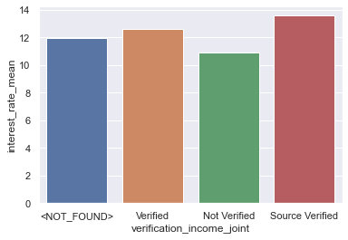

```python
a=sns.barplot(data=verification_pi , x='verification_income_joint', y='interest_rate_mean')
```

```python
verify_list = data["verified_income"].unique()

list_verfication=[]
for item in verify_list:
    mean_item=data.loc[data.verified_income.str.contains(item)].interest_rate.median()
    list_verfication.append([item, mean_item])
verify_pi = pd.DataFrame(list_verfication,columns=["verified_income","interest_rate_mean"])
print(tabulate(verify_pi, headers='keys', tablefmt='psql'))
```

```
+----+-------------------+----------------------+
|    | verified_income   |   interest_rate_mean |
|----+-------------------+----------------------|
|  0 | Verified          |                11.98 |
|  1 | Not Verified      |                10.41 |
|  2 | Source Verified   |                11.99 |
+----+-------------------+----------------------+
```

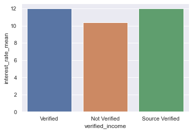

```python
a=sns.barplot(data=verify_pi , x='verified_income', y='interest_rate_mean')
```

### Observation:

On plotting the 'verified_income' and 'verification_income_joint' columns wrt 'interest_rate' it can be found that means are diffrent for diffrent categories though the set of values are same. Thus 'verification_income_joint' can be retained and is useful feature and is not that important for prediction.

### 7.loan_purpose

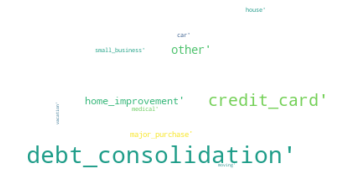

```python
wc = WordCloud(background_color="white")
wc.generate(str(list(data["loan_purpose"])))
plt.imshow(wc,interpolation="bilinear")
plt.axis("off")
plt.show()
```

### Observation:

From the Above Word-Cloud it is evident that debt_consolidation , credit_card , 'home_improvemnet' are the values for which loan is taken mostly

```python
loan_list = data["loan_purpose"].unique()

loan_verfication=[]
for item in loan_list:
    mean_item=data.loc[data.loan_purpose.str.contains(item)].interest_rate.median()
    loan_verfication.append([item, mean_item])
loan_pi = pd.DataFrame(loan_verfication,columns=["loan_purpose","interest_rate_mean"])
print(tabulate(loan_pi, headers='keys', tablefmt='psql'))
```

```
+----+--------------------+----------------------+
|    | loan_purpose       |   interest_rate_mean |
|----+--------------------+----------------------|
|  0 | moving             |               12.61  |
|  1 | debt_consolidation |               11.99  |
|  2 | other              |               11.98  |
|  3 | credit_card        |               10.9   |
|  4 | home_improvement   |               10.9   |
|  5 | medical            |               10.905 |
|  6 | house              |               10.42  |
|  7 | small_business     |               12.61  |
|  8 | car                |               10.9   |
|  9 | major_purchase     |               10.9   |
| 10 | vacation           |               13.58  |
| 11 | renewable_energy   |               12.305 |
+----+--------------------+----------------------+
```

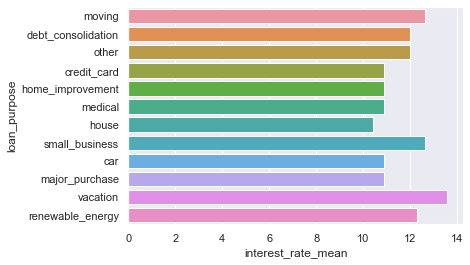

```python
a=sns.barplot(data=loan_pi , x='interest_rate_mean', y='loan_purpose')
```

### Observation:

From the above bar chart it is evident that 'vacation' data has the highest interest value and 'house' has the least average 'interest_rate' value.

### 8.application_type

```python
data['application_type'].unique()
```

```
array(['individual', 'joint'], dtype=object)
```

```python
app=data.groupby(['application_type']).median()['interest_rate']
print(tabulate(app.to_frame(), headers='keys', tablefmt='psql'))
```

```
+--------------------+-----------------+
| application_type   |   interest_rate |
|--------------------+-----------------|
| individual         |           11.98 |
| joint              |           12.61 |
+--------------------+-----------------+
```

### Observation:

From the above analysis we can see that 'application_type' joint has the highest average 'interest_rate' value

### 9.grade

```python
grade_list = data["grade"].unique()

grade_verfication=[]
for item in grade_list:
    mean_item=data.loc[data.grade.str.contains(item)].interest_rate.median()
    grade_verfication.append([item, mean_item])
    #print(item+" has the median:",mean_item)
grade_pi = pd.DataFrame(grade_verfication,columns=["grade","interest_rate_mean"]).sort_values("interest_rate_mean")
grade_pi.sort_values("interest_rate_mean").style.background_gradient(axis=None)
```

|  | grade | interest_rate_mean |
| --- | --- | --- |
| 2 | A | 6.720000 |
| 3 | B | 10.420000 |
| 0 | C | 14.070000 |
| 1 | D | 19.030000 |
| 5 | E | 24.850000 |
| 4 | F | 28.720000 |
| 6 | G | 30.790000 |

### Observation:

It is Observed that as the grade increases , interest also increases.

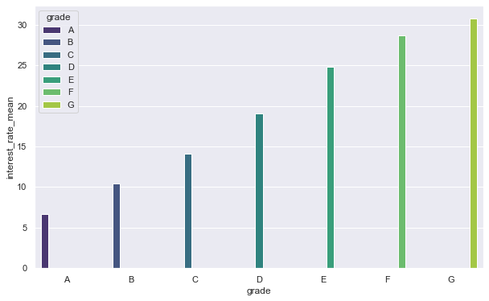

```python
plt.figure(figsize=(10,6))
a=sns.barplot(x=grade_pi["grade"], y=grade_pi["interest_rate_mean"],data=grade_pi,palette="viridis",hue= 'grade')
```

### Observation:

From the above bar graph it is evident that grade 'G' has the highest average interest mean.

### 10.sub_grade

```python
sub_grade=data.groupby(['sub_grade','grade']).mean()['interest_rate']
print(tabulate(sub_grade.to_frame(), headers='keys', tablefmt='psql'))
```

```
+-------------+-----------------+
|             |   interest_rate |
|-------------+-----------------|
| ('A1', 'A') |         5.31555 |
| ('A2', 'A') |         6.07562 |
| ('A3', 'A') |         6.71619 |
| ('A4', 'A') |         7.34572 |
| ('A5', 'A') |         7.96565 |
| ('B1', 'B') |         9.43567 |
| ('B2', 'B') |         9.92611 |
| ('B3', 'B') |        10.4164  |
| ('B4', 'B') |        10.9053  |
| ('B5', 'B') |        11.986   |
| ('C1', 'C') |        12.6156  |
| ('C2', 'C') |        13.5861  |
| ('C3', 'C') |        14.0763  |
| ('C4', 'C') |        15.046   |
| ('C5', 'C') |        16.0159  |
| ('D1', 'D') |        17.2377  |
| ('D2', 'D') |        18.1989  |
| ('D3', 'D') |        19.173   |
| ('D4', 'D') |        20.0964  |
| ('D5', 'D') |        21.5874  |
| ('E1', 'E') |        22.9068  |
| ('E2', 'E') |        23.8765  |
| ('E3', 'E') |        24.8458  |
| ('E4', 'E') |        25.8164  |
| ('E5', 'E') |        26.4963  |
| ('F1', 'F') |        28.72    |
| ('F2', 'F') |        29.69    |
| ('F3', 'F') |        30.17    |
| ('F4', 'F') |        30.65    |
| ('F5', 'F') |        30.75    |
| ('G1', 'G') |        30.79    |
| ('G4', 'G') |        30.94    |
+-------------+-----------------+
```

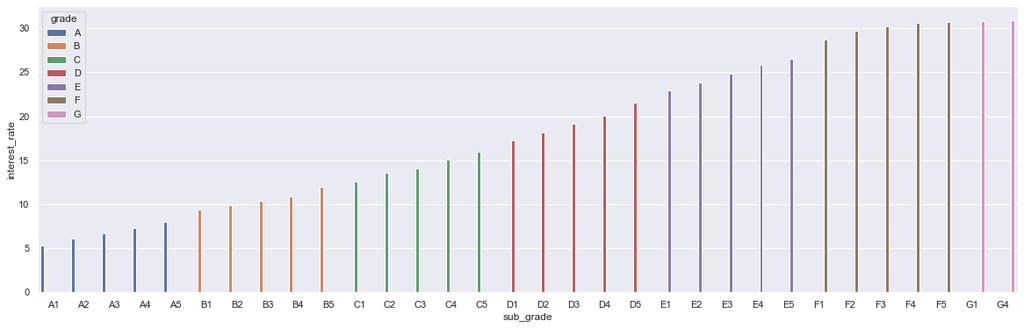

```python
#Analyse the average 'interest_rate' on the basis of subgrade and grade values
plt.figure(figsize=(20,6))
data_sub=data.groupby(['sub_grade','grade']).mean()['interest_rate'].reset_index()
a=sns.barplot(x="sub_grade",y="interest_rate",hue="grade",data=data_sub)
```

### Observation:

From the above bar plot, as the sub-grades increase interest rate also increases.

### 11.issue_month

```python
iss=data.groupby(['issue_month']).mean()['interest_rate']
print(tabulate(iss.to_frame(), headers='keys', tablefmt='psql'))
```

```
+---------------+-----------------+
| issue_month   |   interest_rate |
|---------------+-----------------|
| Feb-2018      |         12.5108 |
| Jan-2018      |         12.3774 |
| Mar-2018      |         12.4058 |
+---------------+-----------------+
```

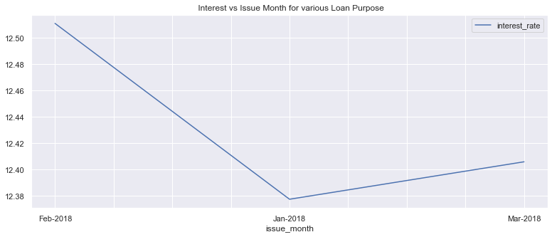

```python
data_time_series = data.groupby(['issue_month']).mean()['interest_rate']
df=data_time_series.to_frame().sort_values("issue_month",ascending=True)
df.plot(figsize=(13, 5));
plt.title(" Interest vs Issue Month for various Loan Purpose");
```

### Observation:

From the time series plot it is evident that 'Jan' has the least interest rate and Feb has the highest interest rate.

### 12.initial_listing_status

```python
data.initial_listing_status.unique()
```

```
array(['whole', 'fractional'], dtype=object)
```

```python
ini=data.groupby(['initial_listing_status']).mean()['interest_rate']
print(tabulate(ini.to_frame(), headers='keys', tablefmt='psql'))
```

```
+--------------------------+-----------------+
| initial_listing_status   |   interest_rate |
|--------------------------+-----------------|
| fractional               |         13.4975 |
| whole                    |         12.1936 |
+--------------------------+-----------------+
```

### Observation:

'fractional' listing status has higher interest value.

### 13.disbursement_method

```python
data.disbursement_method.unique()
```

```
array(['Cash', 'DirectPay'], dtype=object)
```

```python
disbur=data.groupby(['disbursement_method']).mean()['interest_rate']
print(tabulate(disbur.to_frame(), headers='keys', tablefmt='psql'))
```

```
+-----------------------+-----------------+
| disbursement_method   |   interest_rate |
|-----------------------+-----------------|
| Cash                  |        12.6619  |
| DirectPay             |         9.38799 |
+-----------------------+-----------------+
```

### Observation:

'Cash' mode has highest interest_rate when compared to DirectPay values.

# Outlier Analysis of Numerical Features

```python
num=data.columns[data.dtypes.values==(np.dtype('float64'))]
print((num))
int_num=data.columns[data.dtypes.values==(np.dtype('int64'))]
print((int_num))
```

```
Index(['emp_length', 'annual_income', 'debt_to_income', 'annual_income_joint',
       'debt_to_income_joint', 'months_since_last_delinq',
       'months_since_90d_late', 'months_since_last_credit_inquiry',
       'num_accounts_120d_past_due', 'account_never_delinq_percent',
       'interest_rate', 'installment', 'balance', 'paid_total',
       'paid_principal', 'paid_interest', 'paid_late_fees'],
      dtype='object')
Index(['delinq_2y', 'earliest_credit_line', 'inquiries_last_12m',
       'total_credit_lines', 'open_credit_lines', 'total_credit_limit',
       'total_credit_utilized', 'num_collections_last_12m',
       'num_historical_failed_to_pay', 'current_accounts_delinq',
       'total_collection_amount_ever', 'current_installment_accounts',
       'accounts_opened_24m', 'num_satisfactory_accounts',
       'num_accounts_30d_past_due', 'num_active_debit_accounts',
       'total_debit_limit', 'num_total_cc_accounts', 'num_open_cc_accounts',
       'num_cc_carrying_balance', 'num_mort_accounts', 'tax_liens',
       'public_record_bankrupt', 'loan_amount', 'term'],
      dtype='object')
```

```python
numerical_features=['emp_length', 'annual_income', 'debt_to_income', 'annual_income_joint','debt_to_income_joint', 'months_since_last_delinq',
       'months_since_90d_late', 'months_since_last_credit_inquiry',
       'num_accounts_120d_past_due', 'account_never_delinq_percent',
       'interest_rate', 'installment', 'balance', 'paid_total',
       'paid_principal', 'paid_interest', 'paid_late_fees','delinq_2y', 'earliest_credit_line', 'inquiries_last_12m',
       'total_credit_lines', 'open_credit_lines', 'total_credit_limit',
       'total_credit_utilized', 'num_collections_last_12m',
       'num_historical_failed_to_pay', 'current_accounts_delinq',
       'total_collection_amount_ever', 'current_installment_accounts',
       'accounts_opened_24m', 'num_satisfactory_accounts',
       'num_accounts_30d_past_due', 'num_active_debit_accounts',
       'total_debit_limit', 'num_total_cc_accounts', 'num_open_cc_accounts',
       'num_cc_carrying_balance', 'num_mort_accounts', 'tax_liens',
       'public_record_bankrupt', 'loan_amount', 'term']
print(len(numerical_features))
```

```
42
```

```
emp_length
```

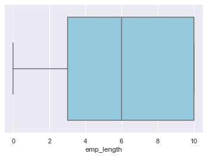

```
emp_length feature has: 0 outliers.

annual_income
```

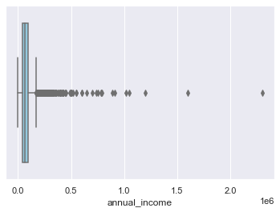

```
annual_income feature has: 508 outliers.

debt_to_income
```

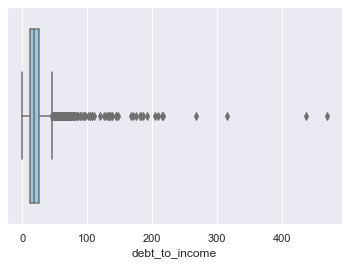

```
debt_to_income feature has: 221 outliers.

annual_income_joint
```

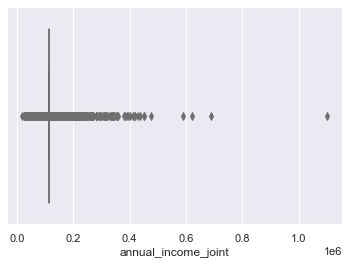

```
annual_income_joint feature has: 1488 outliers.

debt_to_income_joint
```

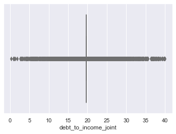

```
debt_to_income_joint feature has: 1493 outliers.

months_since_last_delinq
```

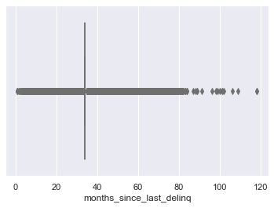

```
months_since_last_delinq feature has: 4271 outliers.

months_since_90d_late
```

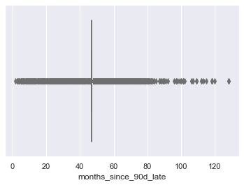

```
months_since_90d_late feature has: 2249 outliers.

months_since_last_credit_inquiry
```

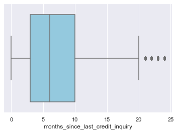

```
months_since_last_credit_inquiry feature has: 320 outliers.

num_accounts_120d_past_due
```

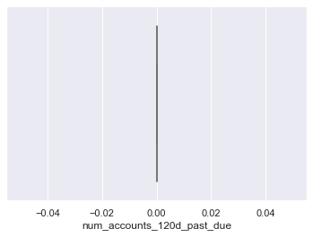

```
num_accounts_120d_past_due feature has: 0 outliers.

account_never_delinq_percent
```

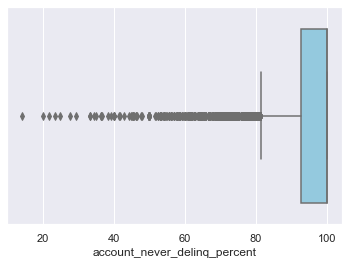

```
account_never_delinq_percent feature has: 883 outliers.

interest_rate
```

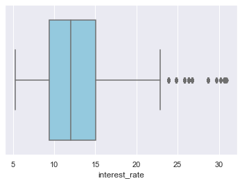

```
interest_rate feature has: 364 outliers.

installment
```

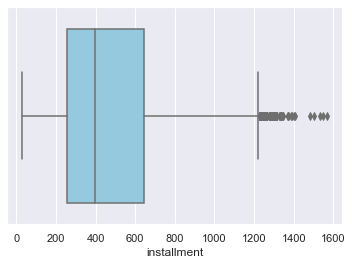

```
installment feature has: 208 outliers.

balance
```

[30 more figures not shown]

```
term feature has: 0 outliers.
```

```python
fig,ax=plt.subplots()
for i in range(len(numerical_features)):
    print(numerical_features[i])
    data[numerical_features[i]].replace(np.nan, data[numerical_features[i]].median(), inplace=True)
    arr=data[numerical_features[i]]
    sns.set(style="darkgrid")
    ax=sns.boxplot(x=arr,color='skyblue')
    plt.show()
    q1=arr.quantile(q=0.25)
    q3=arr.quantile(q=0.75)
    iqr=q3-q1
    left_min=q1-1.5*iqr
    right_max=q3+1.5*iqr
    outliers=data[(arr>right_max)|(arr <left_min)]
    #print(numerical_features[i],"feature has:",len(outliers),"outliers.\n")

    print(numerical_features[i],"feature has:",len(outliers),"outliers.\n")
```

### Observation:

1. There are many numerical features with higher number of outliers, log transformation techniques can be applied to handle them

## Vectorization

```python
#Dependent variable
Y = data[["interest_rate"]]
X = data.drop(["interest_rate"], axis=1)
```

```python
#train-test aplit
X_train, X_test, Y_train, Y_test = train_test_split(X, Y, test_size = 0.2)
```

```python
#Emp title can be considered as a text feature.
text_features = ["emp_title"]
#Categorical featured
cat_features = list(data.columns[data.dtypes.values==(np.dtype('object'))])[1:]

#Numerical features
numerical_features = list(data.columns[data.dtypes.values==np.dtype('int64')])
numerical_features.extend(list(data.columns[data.dtypes.values==np.dtype("float64")]))
numerical_features.remove("interest_rate")
```

```python
from sklearn.feature_extraction.text import TfidfVectorizer
```

```python
#Vectorize the text feature.
vec = TfidfVectorizer()
train_text = vec.fit_transform(X_train["emp_title"].values)
test_text = vec.transform(X_test["emp_title"].values)
```

```python
from sklearn.preprocessing import OneHotEncoder

encoded_train =[]
encoded_test = []

for feature in cat_features:

    encoder = OneHotEncoder(handle_unknown="ignore")

    #one-hot encoding .
    temp_train = encoder.fit_transform(X_train[feature].values.reshape(-1,1))
    temp_test = encoder.transform(X_test[feature].values.reshape(-1,1))

    encoded_train.append(temp_train)
    encoded_test.append(temp_test)
```

### log transformation

```python
# applying log transformations on numerical data as many of them has outliers which improves the MSE.
num_train = np.log(X_train[numerical_features].values + 1e-9)
num_test = np.log(X_test[numerical_features].values + 1e-9)
```

```python
from scipy.sparse import hstack

#Stack the features horizontally.
train_features = hstack((train_text,*encoded_train,num_train))
test_features = hstack((test_text,*encoded_test,num_test))
```

```python
train_features.shape, test_features.shape
```

```
((8000, 2114), (2000, 2114))
```

## Modeling

#### Linear Regression

```python
from sklearn.linear_model import LinearRegression
from sklearn.metrics import mean_squared_error

#I'm not tuning parameters since it has no major hyper-parameters

model = LinearRegression()
model.fit(train_features,Y_train.values)

y_train_pred = model.predict(train_features)
y_test_pred = model.predict(test_features)

print("Mean Squared Error on Train data :",mean_squared_error(y_train_pred, Y_train.values))
print("Mean Squared Error on Test data :",mean_squared_error(y_test_pred, Y_test.values))
```

```
Mean Squared Error on Train data : 0.019478588345998873
Mean Squared Error on Test data : 0.006986106596992552
```

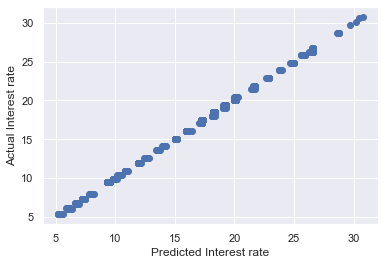

```python
plt.scatter(y_test_pred,Y_test.values)
plt.xlabel("Predicted Interest rate")
plt.ylabel("Actual Interest rate")
```

### RandomForest Regressor

```python
from sklearn import ensemble
from sklearn.metrics import mean_squared_error
from sklearn.model_selection import GridSearchCV

#Hyper-paramtere tuning
tuned_parameters = {'n_estimators': [2,5,10],} # not tuning  many parameters as there is no time
model = GridSearchCV(ensemble.RandomForestRegressor(), tuned_parameters, cv=5, n_jobs=-1, verbose=1)
model.fit(train_features,Y_train.values.reshape(-1))
print(model.best_estimator_)

y_train_pred_rand = model.predict(train_features)
y_test_pred_rand = model.predict(test_features)

print("Mean Squared Error on Train data :",mean_squared_error(y_train_pred, Y_train.values))
print("Mean Squared Error on Test data :",mean_squared_error(y_test_pred, Y_test.values))
```

```
Fitting 5 folds for each of 3 candidates, totalling 15 fits
```

```
[Parallel(n_jobs=-1)]: Using backend LokyBackend with 8 concurrent workers.
[Parallel(n_jobs=-1)]: Done  15 out of  15 | elapsed:   18.4s finished
```

```
RandomForestRegressor(n_estimators=2)
Mean Squared Error on Train data : 0.019478588345998873
Mean Squared Error on Test data : 0.006986106596992552
```

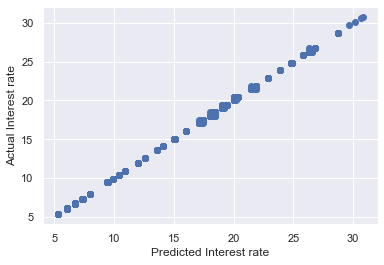

```python
plt.scatter(y_test_pred_rand,Y_test.values)
plt.xlabel("Predicted Interest rate")
plt.ylabel("Actual Interest rate")
```

### Enhancments:

There is no scope for enhancement as the models are performing well .

----------------------------------------------------------- The End -----------------------------------------------------